# Tutorial 10 — Cross-Resistance and Collateral Sensitivity

**Prerequisites:** Tutorials 01–09

When two phages share structural or functional overlap, resistance to one can affect a bacterium's interaction with the other. This is **cross-resistance** (resistance to A reduces susceptibility to B) or **collateral sensitivity** (resistance to A *increases* susceptibility to B).

**What you will learn**

1. The unified CR/CS framework — one formula, any parameter
2. CR/CS on adsorption rates (`cr_adsorption_s`, `cr_adsorption_r`)
3. CR/CS on burst size (`cr_burst_size_s`, `cr_burst_size_r`)
4. CR/CS on mutation rate (`cr_mu`) — evolutionary dynamics
5. CR/CS on fitness cost (`cr_fitness_cost`) — epistatic interactions
6. Co-mutation (legacy `cross_resistance_prob`) — mutation graph routing
7. Summary

## 1 Imports and shared objects

```python
import numpy as np
import dataclasses
import matplotlib.pyplot as plt

from pbisim import PBIModel, solve_ode, DoseEvent, DoseSchedule
from pbisim.strains import BinaryResistanceGenotypes, BacterialStrain, PhageStrain

T_END = 24.0

bacteria = BacterialStrain(base_growth_rate=1.0, bacteria_to_resource_ratio=1e9)

def _phi(name, adsorption_s=2e-9, mu=5e-4, fitness_cost=0.06,
         decay_rate=0.1, burst_size_s=50.0):
    return PhageStrain(
        name=name,
        adsorption_s=adsorption_s,  adsorption_r=0.0,
        adsorption_dormant_s=adsorption_s * 0.01, adsorption_dormant_r=0.0,
        burst_size_s=burst_size_s,  burst_size_r=40.0,
        latent_period_s=0.5,        latent_period_r=0.5,
        latent_period_dormant_s=1.0, latent_period_dormant_r=1.0,
        fitness_cost=fitness_cost,  mu=mu, decay_rate=decay_rate,
    )

phi0 = _phi("phi0", adsorption_s=2e-8, mu=5e-4)
phi1 = _phi("phi1", adsorption_s=1e-9,  mu=3e-4)

def _sim(brg, phage_doses, B0=None, t_end=T_END):
    cfg = brg.to_config(n_latent=5, n_depth=1,
                        monod_constant=0.3, recycle_fraction=0.0)
    events = [DoseEvent(time=0, amount=d, target="phage", index=j)
              for j, d in enumerate(phage_doses)]
    cfg_d  = dataclasses.replace(cfg, dose_schedule=DoseSchedule(events))
    if B0 is None:
        B0 = brg.equilibrium_initial_condition(5e7)
    return solve_ode(
        PBIModel(cfg_d, initial_B=B0, initial_P=np.zeros(len(phage_doses)),
                 initial_S=1.0),
        t_end=t_end, dt=0.25,
    )

print("Setup complete.")
```

```
Setup complete.
```

## 2 The unified CR/CS framework

CR/CS is modelled as a set of **multiplicative factor matrices** — one per parameter variant. Every parameter that has a susceptible (`_s`) and resistant (`_r`) base value, or a single per-locus value (`mu`, `fitness_cost`, …), has a corresponding optional matrix.

For parameter **X** (e.g. `adsorption_s[j]`), the effective value for strain *s* interacting with phage *j* is:

```
X_eff[s, j] = X_base[j]  ×  exp( G[s, :] · log(cr_X[:, j]) )
```

- `G[s, :]` — the full binary genotype vector of strain *s* (length `n_loci = n_phages + n_antibiotics`).
- `cr_X` — the `(n_loci, m)` matrix of CR/CS factors.
- `cr_X[i, j] < 1` — cross-resistance: locus *i* reduces X for phage *j*.
- `cr_X[i, j] > 1` — collateral sensitivity: locus *i* increases X for phage *j*.
- `cr_X[i, j] = 1.0` (or `None`) — no cross-effect.

Multiple carried loci compound **multiplicatively** (log-linear accumulation). The source locus rows span all loci — phage rows (0..m−1) and antibiotic rows (m..n_loci−1) — so all four cross-domain directions are supported.

**Legacy parameters** (`cross_resistance`, `cross_resistance_prob`, `phage_abx_ec50_factor`) continue to work unchanged.

## 3 CR/CS on adsorption

`cr_adsorption_s[i, j]` scales the **susceptible** adsorption rate of phage *j* in strains that carry resistance to phage *i*. `cr_adsorption_r[i, j]` does the same for the **resistant** adsorption rate.

Using separate matrices for `_s` and `_r` gives independent control: CR on susceptible bacteria (e.g., alternative-receptor exposure) need not carry over to already-resistant bacteria.

**Biological scenario:** resistance to phi0 occurs via mutation in a surface receptor that phi1 also binds weakly. In phi0-resistant bacteria:

- *Cross-resistance* (`cr < 1`): the receptor change also blocks phi1.
- *Collateral sensitivity* (`cr > 1`): the structural change exposes a site phi1 exploits more efficiently.

```
Baseline (no CR/CS)               adsorption_s[10, phi1] = 1.000e-09
```

```
Cross-resistance (cr=0.05)        adsorption_s[10, phi1] = 5.000e-11
```

```
Collateral sens. (cr=8)           adsorption_s[10, phi1] = 8.000e-09
```

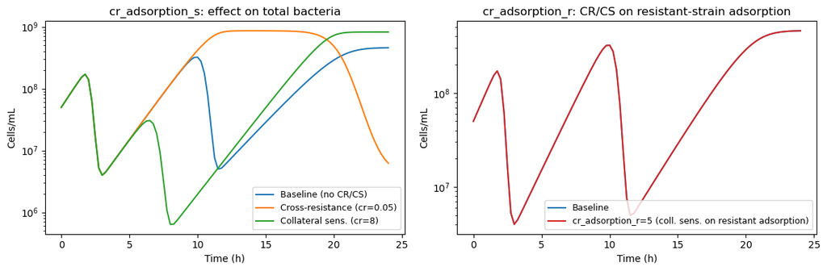

```python
# n_loci = 2 (no antibiotics), shape (2, 2)
# cr_adsorption_s[0, 1] = factor applied to adsorption_s[1] when locus 0 is present
scenarios = [
    (np.array([[1.0, 1.0], [1.0, 1.0]]),  "C0", "Baseline (no CR/CS)"),
    (np.array([[1.0, 0.05],[1.0, 1.0]]),  "C1", "Cross-resistance (cr=0.05)"),
    (np.array([[1.0, 8.0], [1.0, 1.0]]),  "C2", "Collateral sens. (cr=8)"),
]

fig, axes = plt.subplots(1, 2, figsize=(12, 4))
for cr_s_val, color, label in scenarios:
    brg = BinaryResistanceGenotypes.from_strains(
        phages=[phi0, phi1], bacteria=bacteria,
        cr_adsorption_s=cr_s_val,
    )
    res = _sim(brg, [5e3, 5e3])
    B_tot = res.sum_prefixes("B","I","D","H")
    axes[0].semilogy(res.time, np.maximum(B_tot, 1), color=color, label=label)

    # Strain "10" (phi0-resistant, phi1-susceptible): verify effective adsorption
    idx_10 = brg.strain_labels.index("10")
    print(f"{label:32s}  adsorption_s[10, phi1] = {brg.adsorption_rates[idx_10, 1]:.3e}")

axes[0].set(xlabel="Time (h)", ylabel="Cells/mL",
            title="cr_adsorption_s: effect on total bacteria")
axes[0].legend(fontsize=9)

# Also compare cr_adsorption_r: affects resistant-bacteria adsorption rate
cr_r_cs = np.array([[1.0, 5.0], [1.0, 1.0]])   # phi0-resistance increases adsorption_r of phi1
brg_cr_r = BinaryResistanceGenotypes.from_strains(
    phages=[phi0, phi1], bacteria=bacteria,
    cr_adsorption_r=cr_r_cs,
)
res_cr_r = _sim(brg_cr_r, [5e3, 5e3])
brg_base = BinaryResistanceGenotypes.from_strains(phages=[phi0, phi1], bacteria=bacteria)
res_base = _sim(brg_base, [5e3, 5e3])
for (res, color, label) in [
    (res_base, "C0", "Baseline"),
    (res_cr_r, "C3", "cr_adsorption_r=5 (coll. sens. on resistant adsorption)"),
]:
    axes[1].semilogy(res.time, np.maximum(res.sum_prefixes("B","I","D","H"), 1),
                     color=color, label=label)
axes[1].set(xlabel="Time (h)", ylabel="Cells/mL",
            title="cr_adsorption_r: CR/CS on resistant-strain adsorption")
axes[1].legend(fontsize=9)
plt.tight_layout()
plt.show()
```

## 4 CR/CS on burst size

`cr_burst_size_s[i, j]` scales the **burst size** of phage *j* from susceptible bacteria carrying resistance locus *i*.

**Biological scenario:** resistance to phi0 involves down-regulation of a membrane protein that phi1 depends on for genome injection efficiency.

- Cross-resistance (`cr < 1`): phi1 produces fewer progeny from phi0-resistant cells — its killing efficacy drops.
- Collateral sensitivity (`cr > 1`): the membrane remodelling exposes an alternative entry pathway phi1 exploits for even larger bursts.

Crucially, `cr_adsorption_s` and `cr_burst_size_s` are **independent** and can be set simultaneously, allowing fine-grained phenotypic modelling.

```
cr_burst_size_s=1.0: burst_s[phi1] for strain '10' = 50.0
```

```
cr_burst_size_s=0.1: burst_s[phi1] for strain '10' = 5.0
```

```
cr_burst_size_s=8.0: burst_s[phi1] for strain '10' = 400.0
```

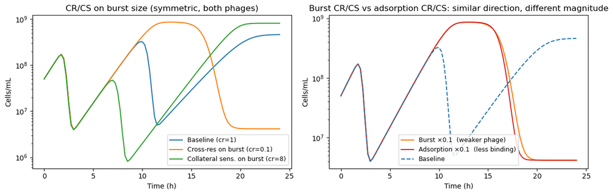

```python
fig, axes = plt.subplots(1, 2, figsize=(12, 4))

# Left: different cr_burst_size_s factors vs baseline
burst_scenarios = [
    (1.0, "C0", "Baseline (cr=1)"),
    (0.1, "C1", "Cross-res on burst (cr=0.1)"),
    (8.0, "C2", "Collateral sens. on burst (cr=8)"),
]
brg_base = BinaryResistanceGenotypes.from_strains(phages=[phi0, phi1], bacteria=bacteria)
B0_base  = brg_base.equilibrium_initial_condition(5e7)

for cr_val, color, label in burst_scenarios:
    cr_bs = np.array([[1.0, cr_val], [cr_val, 1.0]])  # symmetric for both phages
    brg = BinaryResistanceGenotypes.from_strains(
        phages=[phi0, phi1], bacteria=bacteria,
        cr_burst_size_s=cr_bs,
    )
    res = _sim(brg, [5e3, 5e3], B0=B0_base.copy())
    axes[0].semilogy(res.time, np.maximum(res.sum_prefixes("B","I","D","H"), 1),
                     color=color, label=label)
    idx_10 = brg.strain_labels.index("10")
    print(f"cr_burst_size_s={cr_val}: burst_s[phi1] for strain '10' = "
          f"{brg.burst_sizes[idx_10, 1]:.1f}")

axes[0].set(xlabel="Time (h)", ylabel="Cells/mL",
            title="CR/CS on burst size (symmetric, both phages)")
axes[0].legend(fontsize=9)

# Right: compare against equivalent adsorption CR/CS
# A large burst reduction (0.1×) vs an equivalent adsorption reduction (0.1×)
cr_bs_low = np.array([[1.0, 0.1], [0.1, 1.0]])
cr_ad_low = np.array([[1.0, 0.1], [0.1, 1.0]])
for (kw, color, label) in [
    ({"cr_burst_size_s": cr_bs_low},  "C1", "Burst ×0.1  (weaker phage)"),
    ({"cr_adsorption_s": cr_ad_low},  "C3", "Adsorption ×0.1  (less binding)"),
    ({},                               "C0", "Baseline"),
]:
    brg = BinaryResistanceGenotypes.from_strains(phages=[phi0, phi1], bacteria=bacteria, **kw)
    res = _sim(brg, [5e3, 5e3], B0=B0_base.copy())
    axes[1].semilogy(res.time, np.maximum(res.sum_prefixes("B","I","D","H"), 1),
                     color=color, label=label, linestyle="--" if "Baseline" in label else "-")
axes[1].set(xlabel="Time (h)", ylabel="Cells/mL",
            title="Burst CR/CS vs adsorption CR/CS: similar direction, different magnitude")
axes[1].legend(fontsize=9)
plt.tight_layout()
plt.show()
```

## 5 CR/CS on mutation rate

`cr_mu[i, j]` scales the **per-locus mutation rate** for phage-resistance locus *j* in strains that already carry resistance to phage *i*.

**Biological scenario:** resistance to phi0 requires disruption of the lipid A biosynthesis pathway, activating the bacterial SOS response. SOS-active cells have elevated error-prone polymerase activity — a **mutator phenotype** — which increases the mutation rate for all loci, including resistance to phi1.

- `cr_mu[0, 1] > 1` — phi0-resistant bacteria acquire phi1-resistance faster (worse prognosis: double-resistant escape is accelerated).
- `cr_mu[0, 1] < 1` — phi0-resistance *suppresses* mu[1] (rare but biologically plausible if the same receptor is used and the structural change makes additional mutations structurally costly).

Unlike adsorption or burst-size CR/CS (which act on phage–bacteria interaction), `cr_mu` acts on the **evolutionary trajectory**: it changes how quickly double-resistant strains accumulate, visible in the `B3` (strain "11") dynamics.

```
cr_mu= 1.0: mu_eff['10', locus1] = 3.00e-04  (baseline: 3.00e-04)
```

```
cr_mu=10.0: mu_eff['10', locus1] = 3.00e-03  (baseline: 3.00e-04)
```

```
cr_mu= 0.1: mu_eff['10', locus1] = 3.00e-05  (baseline: 3.00e-04)
```

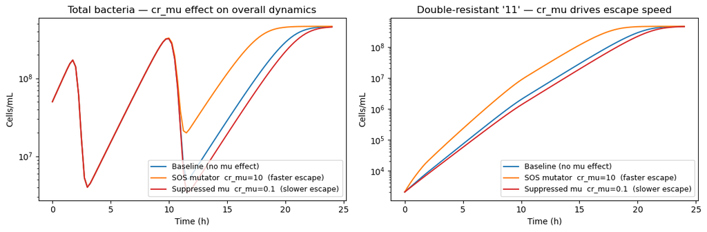

```python
fig, axes = plt.subplots(1, 2, figsize=(12, 4))

mu_scenarios = [
    (1.0,  "C0", "Baseline (no mu effect)"),
    (10.0, "C1", "SOS mutator  cr_mu=10  (faster escape)"),
    (0.1,  "C3", "Suppressed mu  cr_mu=0.1  (slower escape)"),
]
brg_base = BinaryResistanceGenotypes.from_strains(phages=[phi0, phi1], bacteria=bacteria)
B0_base  = brg_base.equilibrium_initial_condition(5e7)

for cr_val, color, label in mu_scenarios:
    # Asymmetric: phi0-resistance alters mu for phi1 locus (and vice versa)
    cr_mu = np.array([[1.0,    cr_val],
                      [cr_val, 1.0  ]])
    brg = BinaryResistanceGenotypes.from_strains(
        phages=[phi0, phi1], bacteria=bacteria,
        cr_mu=cr_mu,
    )
    res = _sim(brg, [5e3, 5e3], B0=B0_base.copy())

    # Show effective mu for strain "10" (phi0-resistant)
    mu_eff = brg._effective_mu_matrix
    idx_10 = brg.strain_labels.index("10")
    print(f"cr_mu={cr_val:4.1f}: mu_eff['10', locus1] = {mu_eff[idx_10, 1]:.2e}"
          f"  (baseline: {brg.mu[1]:.2e})")

    axes[0].semilogy(res.time, np.maximum(res.sum_prefixes("B","I","D","H"), 1),
                     color=color, label=label)
    axes[1].semilogy(res.time, np.maximum(res.get("B3"), 1),
                     color=color, label=label)

axes[0].set(xlabel="Time (h)", ylabel="Cells/mL",
            title="Total bacteria — cr_mu effect on overall dynamics")
axes[1].set(xlabel="Time (h)", ylabel="Cells/mL",
            title="Double-resistant '11' — cr_mu drives escape speed")
for ax in axes:
    ax.legend(fontsize=9)
plt.tight_layout()
plt.show()
```

## 6 CR/CS on fitness cost (epistatic growth-rate interactions)

`cr_fitness_cost[i, j]` modifies the effective fitness cost of resistance locus *j* when resistance locus *i* is also present.

Without epistasis the growth rate of a doubly-resistant strain is `base × (1 − c₀) × (1 − c₁)`, implying costs multiply independently. `cr_fitness_cost` breaks this assumption:

- `cr_fitness_cost[i, j] > 1` — **synergistic** (super-multiplicative) cost: double-resistance is metabolically more burdensome than expected.
- `cr_fitness_cost[i, j] < 1` — **compensatory** (antagonistic) epistasis: one mutation partially compensates the cost of the other.

Note that `cr_fitness_cost` modifies the effective cost for locus *j* based on all *other* carried loci. Self-interaction (`cr_fitness_cost[j, j]`) acts when locus *j* is present, i.e., it is trivially 1.0 unless you want to model a strain-level growth modifier (unusual).

```
cr_fitness_cost=1.0: growth rates — WT=1.000  R10=0.940  R11=0.884
```

```
cr_fitness_cost=3.0: growth rates — WT=1.000  R10=0.940  R11=0.672
```

```
cr_fitness_cost=0.15: growth rates — WT=1.000  R10=0.940  R11=0.982
```

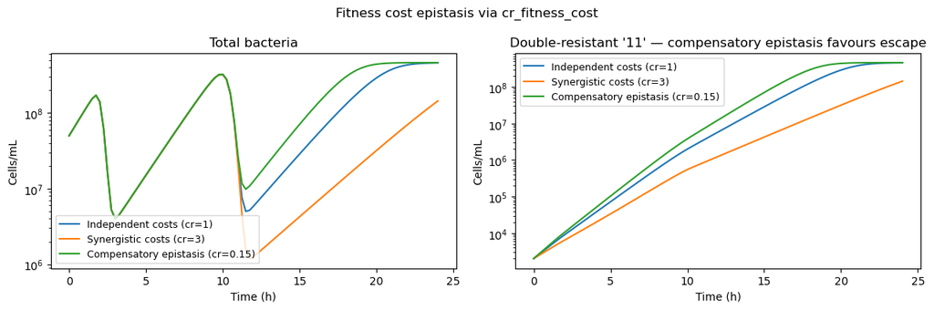

```python
fig, axes = plt.subplots(1, 2, figsize=(12, 4))

cost_scenarios = [
    (1.0,  "C0", "Independent costs (cr=1)"),
    (3.0,  "C1", "Synergistic costs (cr=3)"),
    (0.15, "C2", "Compensatory epistasis (cr=0.15)"),
]
brg_base = BinaryResistanceGenotypes.from_strains(phages=[phi0, phi1], bacteria=bacteria)
B0_base  = brg_base.equilibrium_initial_condition(5e7)

for cr_val, color, label in cost_scenarios:
    cr_fc = np.array([[1.0, cr_val],
                      [cr_val, 1.0]])
    brg = BinaryResistanceGenotypes.from_strains(
        phages=[phi0, phi1], bacteria=bacteria,
        cr_fitness_cost=cr_fc,
    )
    res = _sim(brg, [5e3, 5e3], B0=B0_base.copy())

    labels = brg.strain_labels
    gr = brg.growth_rates
    print(f"cr_fitness_cost={cr_val}: growth rates — "
          f"WT={gr[labels.index('00')]:.3f}  "
          f"R10={gr[labels.index('10')]:.3f}  "
          f"R11={gr[labels.index('11')]:.3f}")

    B_tot = res.sum_prefixes("B","I","D","H")
    axes[0].semilogy(res.time, np.maximum(B_tot, 1), color=color, label=label)
    axes[1].semilogy(res.time, np.maximum(res.get("B3"), 1), color=color, label=label)

axes[0].set(xlabel="Time (h)", ylabel="Cells/mL", title="Total bacteria")
axes[1].set(xlabel="Time (h)", ylabel="Cells/mL",
            title="Double-resistant '11' — compensatory epistasis favours escape")
for ax in axes:
    ax.legend(fontsize=9)
plt.suptitle("Fitness cost epistasis via cr_fitness_cost")
plt.tight_layout()
plt.show()
```

## 7 Co-mutation — `cross_resistance_prob` (legacy)

`cross_resistance_prob[i, j]` is the probability that a **single mutational event** at locus *i* simultaneously confers resistance at locus *j*. This is mechanistically distinct from `cr_mu`:

| Mechanism | Parameter | What it changes |
| --- | --- | --- |
| Elevated background rate | `cr_mu[i, j] > 1` | Strain carrying locus *i* has higher rate of *separate* mutations at *j* |
| Co-mutation | `cross_resistance_prob[i, j]` | A fraction of mutations at *i* **simultaneously** flip *j*, creating a direct `00 → 11` edge |

`cross_resistance_prob` is kept as a distinct mechanism because the direct `00 → 11` edge it creates cannot be replicated by `cr_mu` alone: `cr_mu` only accelerates the background rate after `10` already exists. When double resistance is primarily acquired by a single linked mutation event (e.g., a deletion spanning both receptor genes), `cross_resistance_prob` is the correct model.

Both parameters may be set simultaneously; they stack independently.

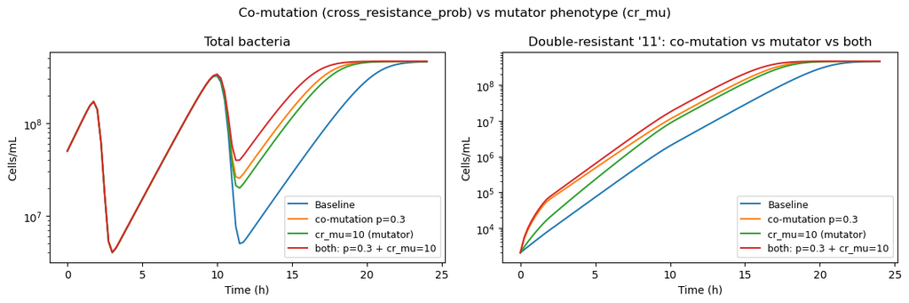

```python
fig, axes = plt.subplots(1, 2, figsize=(12, 4))

brg_base = BinaryResistanceGenotypes.from_strains(phages=[phi0, phi1], bacteria=bacteria)
B0_base  = brg_base.equilibrium_initial_condition(5e7)

for p_val, cr_mu_val, color, label in [
    (0.0, 1.0, "C0", "Baseline"),
    (0.3, 1.0, "C1", "co-mutation p=0.3"),
    (0.0, 10., "C2", "cr_mu=10 (mutator)"),
    (0.3, 10., "C3", "both: p=0.3 + cr_mu=10"),
]:
    kw = {}
    if p_val > 0:
        kw["cross_resistance_prob"] = np.array([[0.0, p_val], [p_val, 0.0]])
    if cr_mu_val != 1.0:
        kw["cr_mu"] = np.array([[1.0, cr_mu_val], [cr_mu_val, 1.0]])
    brg = BinaryResistanceGenotypes.from_strains(phages=[phi0, phi1], bacteria=bacteria, **kw)
    res = _sim(brg, [5e3, 5e3], B0=B0_base.copy())
    B11 = res.get("B3")
    axes[0].semilogy(res.time, np.maximum(res.sum_prefixes("B","I","D","H"), 1),
                     color=color, label=label)
    axes[1].semilogy(res.time, np.maximum(B11, 1), color=color, label=label)

axes[0].set(xlabel="Time (h)", ylabel="Cells/mL", title="Total bacteria")
axes[1].set(xlabel="Time (h)", ylabel="Cells/mL",
            title="Double-resistant '11': co-mutation vs mutator vs both")
for ax in axes:
    ax.legend(fontsize=9)
plt.suptitle("Co-mutation (cross_resistance_prob) vs mutator phenotype (cr_mu)")
plt.tight_layout()
plt.show()
```

## 8 Summary

**One formula — any parameter.** Every per-phage parameter with a `_s` / `_r` base value, or a single per-locus value, has a corresponding CR/CS matrix.

| Parameter | Matrix | Shape | Biological example |
| --- | --- | --- | --- |
| `adsorption_s` / `adsorption_r` | `cr_adsorption_s/r` | (n_loci, m) | Shared receptor — altered binding |
| `burst_size_s` / `burst_size_r` | `cr_burst_size_s/r` | (n_loci, m) | Changed membrane → fewer/more progeny |
| `latent_period_s` / `_r` | `cr_latent_period_s/r` | (n_loci, m) | Altered replication cycle length |
| `mu` | `cr_mu` | (n_loci, m) | SOS activation → mutator phenotype |
| `fitness_cost` | `cr_fitness_cost` | (n_loci, m) | Epistatic cost interactions |
| `antibiotic_ec50_s/r` | `cr_ec50_s/r` | (n_loci, a) | Phage steering → MIC reduction |
| `antibiotic_emax_s/r` | `cr_emax_s/r` | (n_loci, a) | Enhanced antibiotic killing |

The source rows of each matrix span **all** resistance loci (phage + antibiotic), enabling cross-domain effects: phage resistance → antibiotic susceptibility (phage steering) and antibiotic resistance → phage parameters.

**Legacy parameters** (`cross_resistance`, `cross_resistance_prob`, `phage_abx_ec50_factor`) are preserved unchanged and stack with the new matrices when both are set.

**Next tutorial:** *Inter-individual variability and virtual populations* — running batch simulations across a heterogeneous patient cohort.